# Równoważenie obciążenia przez alokację shardów bazującą na predykcji obciążenia

Damian Szkudlarek

Wojciech Taisner

Michał Włodarczyk

# Algorytmy przydziału

### BestFit (BF)

Algorytm redukuje problem alokacji shardów do problemu szeregowania $P || C_{max}$.

Węzły są traktowane jako równoległe maszyny, shardy jako niepodzielne zadania, wektor obciążenia shardu jest redukowany do średniej jego elementów, ta średnia jest długością trwania zadania.

Metoda BestFit w każdej iteracji dodaje shard do węzła, w taki sposób, aby pozostawić jak najmniej wolnego miejsca, dopóki wolne miejsce jest i shard się mieści na węzeł. Po zapełnieniu węzła, algorytm przechodzi do kolejnego. Ewentualne, nie przydzielone shardy są przydzielane kolejno na węzły o najmniejszym obciążeniu.

### RoundRobin (RR)

Podejście naiwne - przydział zadań na węzły po kolei, algorytmem Round Robin, bez uprzedniego szeregowania węzłów.

### SALP

Algorytm pierwotnej alokacji shardów – SALP (Shards Allocation based on Load Prediction) - zgodnie ze specyfikacją.

1. Wyznacz *sumaryczny wektor obciążenia* dla całej chmury $WTS = \sum{W_i}$.
2. Wyznacz względne obciążenie przypadające na jeden węzeł chmury, czyli *znormalizowany wektor obciążenia* $NWTS = \frac{1}{N*WTS}$.
3. Umieść wektory obciążenia $W_i$ wszystkich fragmentów danych na liście $LW$ posortowanej ze względu na malejący moduł. Porządek listy ma zapewnić odpowiednią kolejność alokacji fragmentów danych.
4. Dla każdego węzła utwórz pusty podzbiór fragmentów danych $FS_i$ i pusty wektor obciążenia węzła $WS_i$. Wszystkie węzły zaznacz jako aktywne.
5. Przetwarzaj kolejno elementy $lw_i$ listy $LW$.
1. Dodaj fragment danych $F_i$, do tego aktywnego podzbioru $FS_j$, dla którego dodanie wektora $W_i$ do wektora $WS_j$ zmaksymalizuje wartość różnicy między modułami dwóch wektorów niezrównoważenia obciążenia $\Delta j$: wektora przed potencjalnym dodaniem do niego obciążenia fragmentu $W_i$ i wektora niezrównoważenia po dodaniu obciążenia fragmentu $W_i$, czyli $\Delta (NWTS, WS_j) - \Delta(NWTS, WS_j + W_i)$. Przez wektor niezrównoważenia $\Delta(NWTS, WS_j)$ rozumiemy wektor, który jest różnicą między sumarycznym wektorem obciążenia danego węzła $WS_i$ i wektorem znormalizowanym $NWTS$.
2. Po dodaniu shardu do wybranego węzła modyfikuj jego wektor obciążenia $WS_j = WS_j + W_i$.
3. Jeżeli po tej modyfikacji moduł wektora obciążenia tego węzła $WS_j$ będzie większy niż moduł wektora $NWTS$, to zaznacz ten węzeł jako nieaktywny.

# Eksperyment

## Parametry eksperymentu

Lista wybranych parametrów dla symulacji:

1. Liczba węzłów $N=100$
2. Liczba shardów $F=1000$ (średnio 10 shardów na węzeł)
3. Długość cyklu - liczba elementów w cyklu (size) $S=100$

Sposób generowania danych przez generator rozkładu gamma:

1. Losowanie parametrów skali $\theta$ dla shardów z rozkładu gamma o kształcie $k=2$ i skali $\theta=5$
2. Generowanie $S$ wartości dla każdego z $F$ shardów z rozkładu gamma o kształcie $k=2$ i skali $\theta$ wylosowanej jak opisano w punkcie 1.

Parametry generowania danych w “Nowym modelu obciążenia”:

1. Generacja wartości dolnej $low$ z rozkładu jednostajnego (1,5), generacja wartości $gap$ (wartość górna $high = low + gap$) z rozkładu jednostajnego (1,5)
2. Generacja wartości kąta przechyłu z zakresu <-15; 15> (stopni)
3. Co drugi wektor obciążenia “odwrócony”

## Opis Eksperymentu

W przypadku danych wygenerowanych z rozkładu gamma, dla każdej wartośći współczynnika korelacji z zakresu <0;1> z krokiem 0.05 wygenerowano po 100 różnych zestawów danych, razem 2100 zestawów. Dla każdej generacji, wartość ziarna generatorów liczb losowych była ustalona jako numer powtórzenia, czyli kolejne liczby z zakresu <0;99> (w celu zapewnienia powtarzalności).

W przypadku danych generowanych według “Nowego modelu obciążenia”, ze względu na brak dodatkowej parametryzacji, wygenerowano jedynie 100 razy ten sam zestaw danych, za każdym razem zmieniając ziarno generatora liczb losowych, analogicznie do sposobu opisanego powyżej.

Po uzyskaniu wszystkich zestawów danych, uruchamiano na nich algorytmy w celu uzyskania przydziału shardów do węzłów, a następnie wyliczano wektory obciążenia węzłów. W przypadku danych generowanych z rozkładu gamma, uzyskano łącznie 6300 zestawów obciążeń węzłów, a w drugim wypadku analogicznie 300 zestawów.

Kolejnym krokiem była ewaluacja obciążeń węzłów, dla każdego zestawu i każdej z zadanych wartości współczynnika obciążenia (zakres <0.5; 0.9> krok 0.05), wyliczane były miary według zadanych wzorów.

Niezmienność danych była uzyskiwana poprzez kopiowanie rezultatów uzyskanych przez algorytmy, w przypadku gdy do wektorów obciążeń węzłów były wprowadzanae zmiany, np. gdy była wymagana alokacja nadmiarowego obciążenia.

Kopiowanie uzyskanych rezultatów okazało się bardziej efektywne niż generacja i powtórne szeregowanie takiego samego zestawu danych, co pozwoliło znacząco skrócić czas trwania symulacji.

Powyższy opis można przedstawić przy użyciu poniższego pseudokodu (dla przypadku generacji danych ze współczynnikiem korelacji)

```
# double loop, correlation and repeats
FOR correlaction_coefficient IN <0;1> step 0.05; FOR r IN <0;99>;
BEGIN:
  shards = GENERATE_SHARDS(correlaction_coefficient, seed=r)
  FOR EACH algorithm OF algorithm_list:
  BEGIN:
    nodes = algorithm.shard_assignment(shards)
    FOR load IN <0.5; 0.9> step 0.05
    BEGIN:
      result = evaluate(nodes, load) # copy nodes
      # save  single record of results
      YIELD result
    END
  END
END
```

# Wyniki eksperymentu

Niniejsza sekcja zawiera wykresy prezentujące dane, uzyskane podczas przeprowadzonych symulacji.

## Dane generowane z rozkładu Gamma

### Liczba wyników w zależności od obciążenia

Poniższy wykres prezentuje liczbę poprawnych (takich, gdzie każdy węzeł jest stabilny) przyporządkowań shardów do węzłów wygenerowanych przed dany algorytm w zależności od obciążenia.

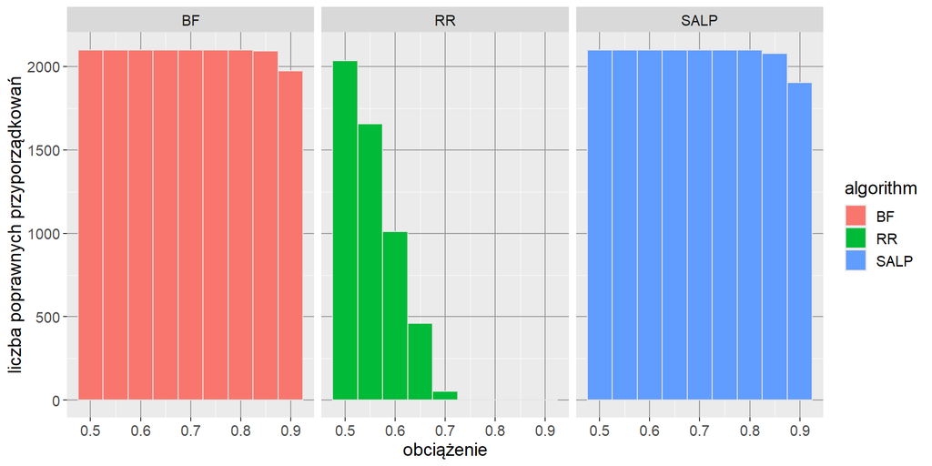

### Czas opóźnień, a korelacja

Poniższe wykresy zestawiają średnie czasy opóźnień (oś Y) w zależności od wartości współczynnika korelacji (oś X) dla obciążeń z zakresu <0.5, 0.7>.

Dla wykresów etykietowanych obciążeniami `0.5` i `0.55`, linia reprezentująca algorytm BestFit jest mało widoczna, lecz pokrywa się z linią algorytmu SALP.

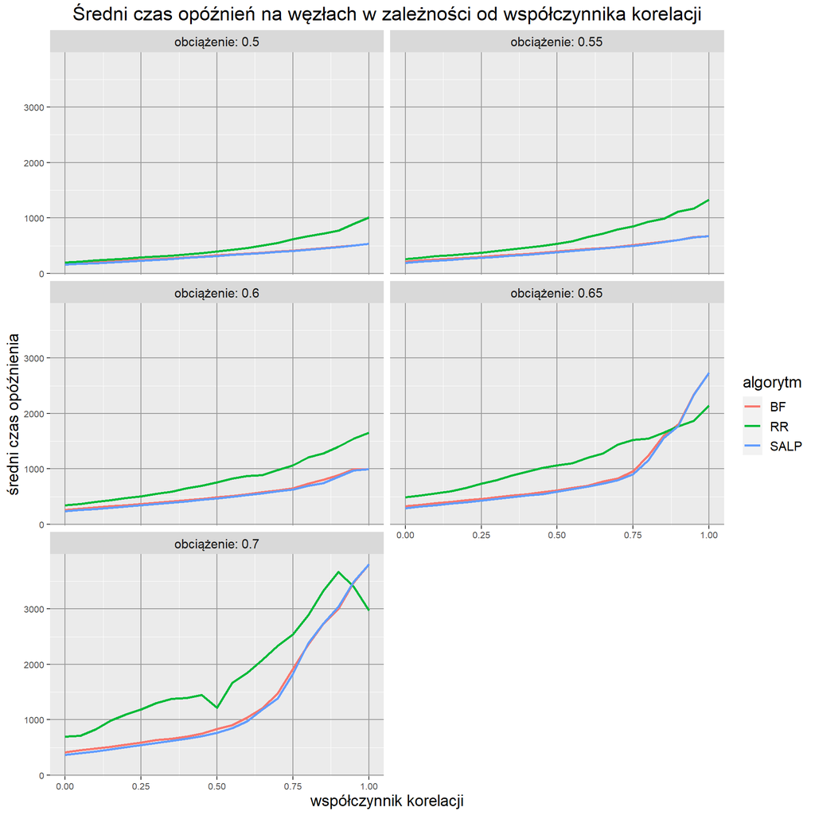

Dla wartości obciążenia większych niż `0.7` przedstawiono zależności na osobnych wykresach, ponieważ potrzebna jest większa skala osi Y. Ponadto z wykresów zniknęła linia reprezentująca algorytm Round Robin, z przyczyn opisanych w powyższej sekcji.

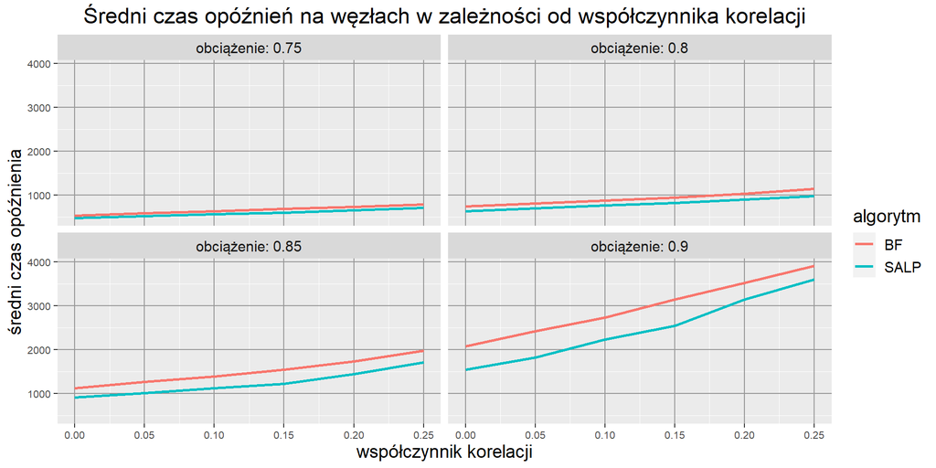

Jednocześnie należy zwrócić uwagę na fakt, że został ograniczony zakres wartości na osi X.

Na wykresach obserwujemy znaczące korzyści z wykorzystania algorytmu do przydziału shardów w stosunku do naiwnego podejścia (Round Robin). Dodatkowo należy zwrócić uwagę na to, że algorytm SALP uzyskuje lepsze wyniki niż BestFit.

### Czas opóźnień, a obciążenie

Poniższe wykresy są uzupełnieniem do poprzedniej sekcji, pokazują zmianę czasu opóźnienia, w stosunku do obciążenia dla wybranych wartości korelacji.

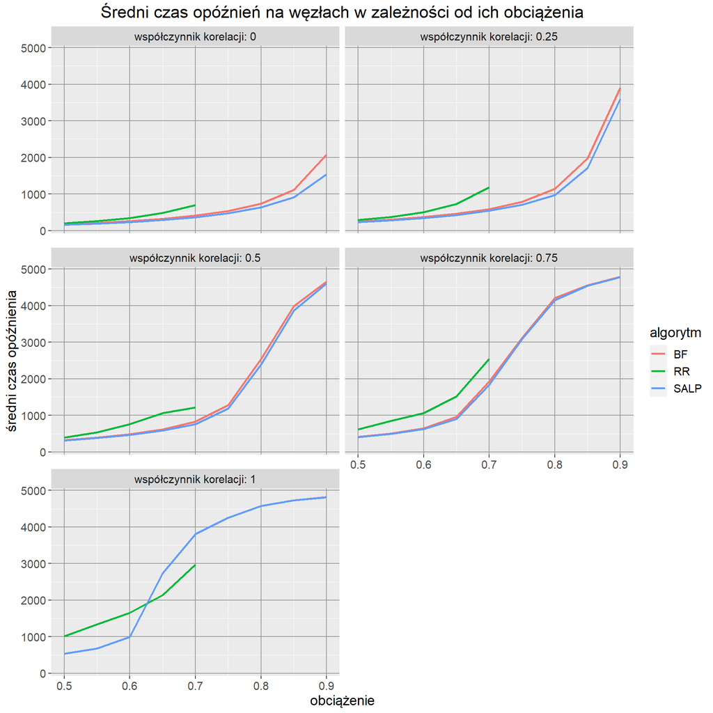

Na powyższych wykresach warto zwrócić uwagę na ostatni - dla współczynnika korelacji równego 1. W przedstawionym wypadku algorytm SALP osiąga praktycznie takie same wyniki jak Best Fit - wynika to z faktu, że dla współczynnika korelacji przebiegi mają taką samą serię wzrostów i spadków, różnią się jedynie skalą. Przez to uniemożliwione jest optymalizowanie niezrównoważenia, co stara się robić algorytm SALP, przez co jednocześnie redukuje się wymiarowość problemu - w związku z brakiem różnic w zmianach przebiegów wektorów obciążenia. W praktyce można je zredukować jedynie do sumarycznego lub średniego obciążenia, a to robi algorytm Best Fit.

### Niezrównoważenie obciążenia, a korelacja

Kolejny wykres prezentuje niezrównoważenie w zależności od współczynnika korelacji.

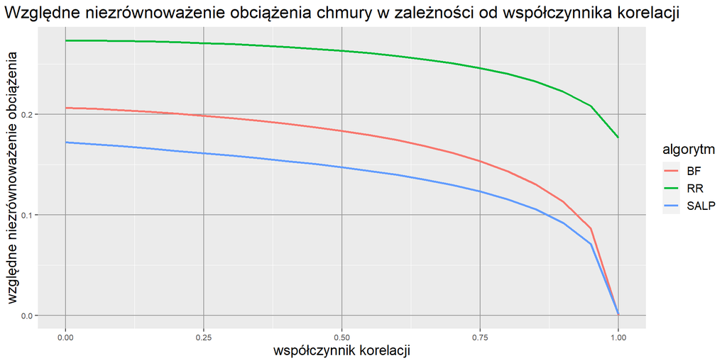

Na powyższym wykresie obserwujemy względne niezrównoważenie obciążenia węzłów, dla wskazancyh algorytmów w zalezności od współczynnika korelacji. Potwierdza się teza opisana w poprzednim paragrafie, gdyż dla współczynnika korelacji równego 1 obserwujemy wartość niezrównoważenia równą 0 dla algorytmów SALP i Best Fit.

### Obciążenie chmury, a korelacja

Poniższy wykres dotyczy generowanych danych, linia ciągła prezentuje średnie sumaryczne obciążenie chmury, a prosta linia przerywana to wartość estymowana na podstawie parametrów generacji.

W związku z tym, że w symulacjach były używane te same ziarna losowe generatora, ten wykres obrazuje wpływ transformacji powiązanych z korelacją, na zmiany w generowanych rozkładach.

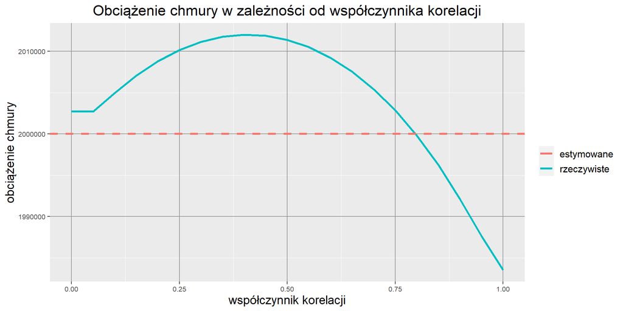

### Współczynnik zmienności częstości przedkładania zadań, a korelacja

Poniższy wykres wskazuje na powiązanie wartości zmienności częstości przedkładania zadań, z wartością współczynnika korelacji.

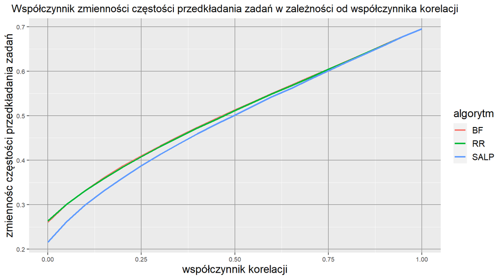

Powyższy wykres wskazuje na istnienie zależności pomiędzy współczynnikiem korelacji a współczynnikiem zmienności częśtości przedkładania zadań.

Jednocześnie można stwierdzić że dla małych wartości współczynnika korelacji algorytm SALP jest w stanie zmniejszać wartość tego współczynnika, jednocześnie redukując czasy opóźnień.

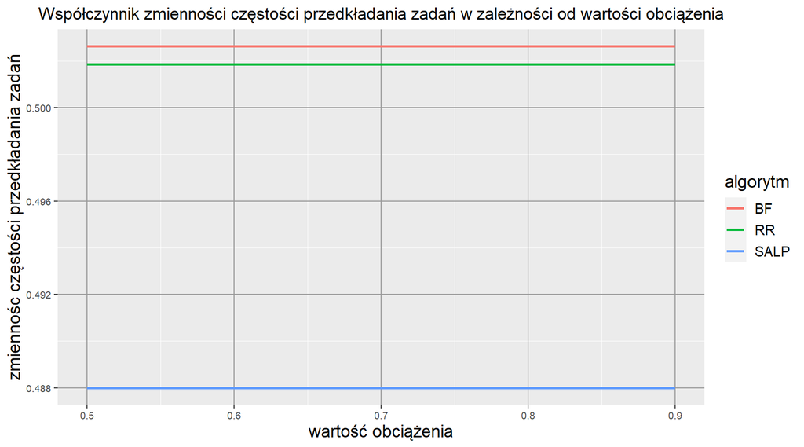

Obserwujemy brak zależności między obciążeniem, a współczynnikiem zmienności częstości przedkładania zadań. Wynika to z tego, że wartość obciążenia nie jest potrzebna, ani na etapie generowania danych, ani na etapie wykonywania algorytmów - przez co wartość obciążenia nie ma wpływu na kolejność zadań.

## Dane generowane według “Nowego modelu obciążenia”

W tej sekcji przedstawione są wyniki dodatkowego eksperymentu, w którym dane były generowane według “nowego modelu obciążenia”. W związku z tym, że dla tak generowanych danych, proces nie uwzględniał zmiany współczynnika korelacji, wystarczy przedstawić jedynie zależność czasu opóźnienia od obciążenia.

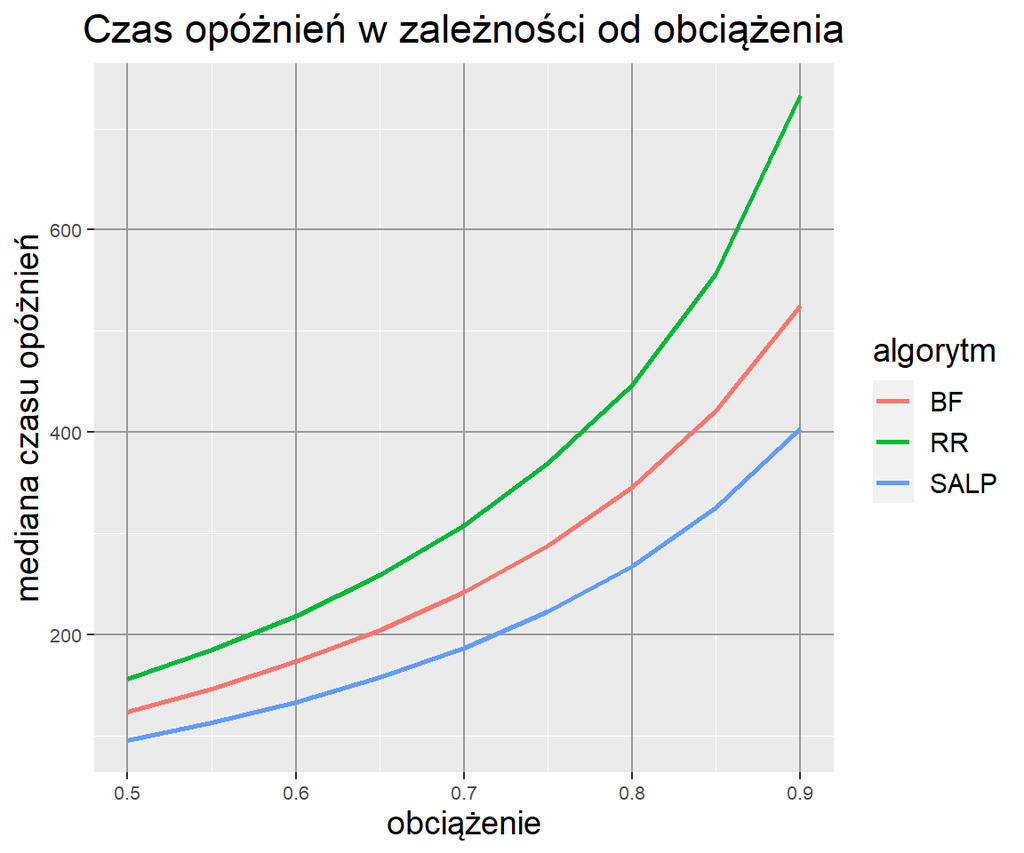

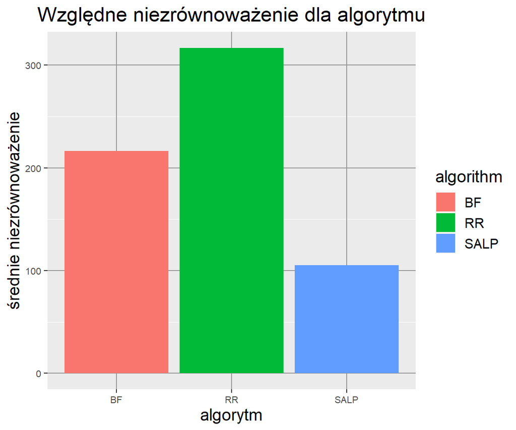

Nowy Model Obciążeń charakteryzuje się tym, że do dobrego przydzielenia shardów, wymagane jest branie pod uwagę niezrównoważenia. Jasne więc jest, że algorytm SALP, który bierze pod uwagę niezrównoważenie, osiąga znacząco lepszy rezultat niż konkurencja.

## Wnioski

Po przeprowadzeniu symulacji, teza zostaje uznana za prawdziwą.

> Algorytm SALP redukuje opóźnienia będące wynikiem chwilowych przeciążeń pojedynczych węzłów chmury w zależności od współczynnika korelacji przebiegów obciążenia różnych shardów.

Ostatecznie, po przeanalizowaniu wyników symulacji, algorytm SALP uzyskiwał najbardziej optymalne rezultaty, wyróżniając się najbardziej w sytuacji, gdy należy optymalizować niezrównoważanie.